# Checking your fitted model

# Introduction

A fitted graphical model raises questions of two kinds. *Which edges does the evidence settle?* is a question about the posterior, and `verdicts()` answers it. *Does the model describe the data?* is a question about fit, and it splits in two: whether the conditional prediction for each variable is calibrated, which `calibration_check()` answers, and whether the joint distribution is reproduced, which you check by building a display on `simulate()`.

This vignette works through all of them on the Wenchuan data. The convergence diagnostics – R-hat, effective sample size, the trust gauge – are a separate matter and live in the diagnostics vignette.

```r
library(bgms)
data = Wenchuan[, 1:9]
fit = bgm(data, seed = 1234)
```

# What the evidence settles

Each edge carries an inclusion Bayes factor, and reading it at a threshold gives one of three verdicts: evidence of presence, evidence of absence, or undecided. The third is not a failure of the analysis; it is the honest answer when the data do not separate the two hypotheses.

```r
edges = verdicts(fit)
edges
```

```
#> Edge verdicts at an inclusion Bayes factor of 10 (and 0.1 for absence):
#> presence: log BF > 2.30; absence: log BF < -2.30
#>
#>   presence 11 | undecided 15 | absence 10   (36 indicators)
#>
#>           parameter   pip  log_bf   verdict fragile
#>    intrusion-dreams 1.000 291.671  presence   FALSE
#>     intrusion-flash 1.000  16.221  presence   FALSE
#>     intrusion-upset 0.947   2.887  presence    TRUE
#>   intrusion-physior 0.632   0.539 undecided   FALSE
#>   intrusion-avoidth 0.026  -3.615   absence   FALSE
#>  intrusion-avoidact 0.038  -3.244   absence   FALSE
#>   intrusion-amnesia 0.036  -3.275   absence   FALSE
#>   intrusion-lossint 0.165  -1.620 undecided   FALSE
#>        dreams-flash 1.000 132.236  presence   FALSE
#>        dreams-upset 0.667   0.695 undecided   FALSE
#> ... (26 more rows)
#>
#> 7 verdicts are Monte-Carlo fragile: a verdict boundary lies within two standard
#> errors of the evidence, so the verdict could change on a rerun. Consider a
#> longer run.
```

The `fragile` column is the part that cannot be read off the Bayes factor alone. A verdict is fragile when a threshold sits within two standard errors of the estimated evidence, which is exactly the regime in which Monte Carlo noise, not the data, decides the answer. In a known-truth calibration study of 37,010 edge-fits across ordinal, binary, and Gaussian graphical models, every verdict error sat within 0.58 of a threshold on the log Bayes factor scale, and no edge further out was ever misclassified.

A fragile verdict is not a wrong verdict; it is a verdict the run is too short to settle. The remedy is more iterations, not a different model.

```r
edges[edges$fragile, c("parameter", "log_bf", "verdict")]
```

```
#>          parameter    log_bf   verdict
#> 3  intrusion-upset  2.887300  presence
#> 12  dreams-avoidth -2.208473 undecided
#> 13 dreams-avoidact -2.524920   absence
#> 16     flash-upset -2.464686   absence
#> 20   flash-amnesia  2.837967  presence
#> 24  upset-avoidact -2.064197 undecided
#> 30 physior-lossint  2.232483 undecided
```

The default picture encodes the same three verdicts, so what a reader sees and what the table says cannot drift apart.

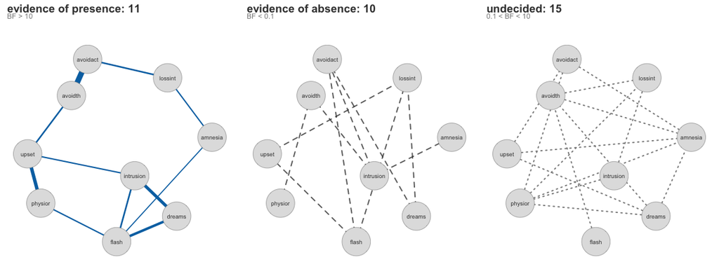

```r
plot(fit)
```

There is one panel per verdict – the pairs the data support, the pairs the data rule out, and the pairs the data cannot decide – drawn on one shared layout, so a variable sits in the same place in all three. Only the first panel is weighted, with line width the posterior mean association and colour its sign; the other two are drawn at uniform width, dashed for a ruled-out pair and dotted for an undecided one, because there the classification is the result. A single drawing would have to leave the last two classes as the same blank, which is exactly what a reader cannot interpret. For one edge in detail, the spike-and-slab posterior shows how the mass is actually divided:

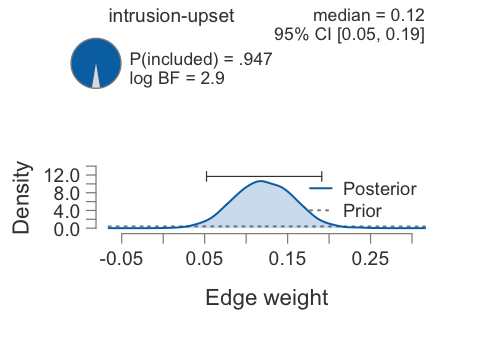

```r
plot_edge_posterior(fit, "intrusion", "upset")
```

Centrality is a function of the graph, so it inherits the same uncertainty. Evaluating it on every posterior draw gives its posterior directly, which is what `extract_centrality()` returns.

```r
strength = extract_centrality(fit)
head(summary(strength))
```

```
#>        node      mean     lower     upper p_most_central
#> 6   avoidth 0.8754598 0.7461277 1.0248335         0.5605
#> 7  avoidact 0.8570654 0.7355831 0.9941833         0.3965
#> 4     upset 0.7399619 0.6218007 0.8629425         0.0310
#> 2    dreams 0.7051229 0.5926109 0.8192193         0.0085
#> 5   physior 0.6776066 0.5664244 0.8046862         0.0025
#> 1 intrusion 0.6626375 0.5596425 0.7838838         0.0010
```

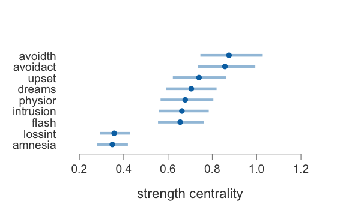

```r
plot(strength)
```

# Are the conditional predictions calibrated?

The model’s person-level predictions are the conditional distributions `P(x_ij | the rest of case i's responses)`, which is the model’s own regression unit. `calibration_check()` compares those predictions with what was observed, one variable at a time: an isotonic fit of observed frequency on predicted probability for a discrete variable, and the probability integral transform for a continuous one.

```r
calibration = calibration_check(fit, nrep = 200, seed = 1)
calibration
```

```
#> Calibration of the conditional predictions, 95% consistency band from 200 resamples:
#>
#>   variable kind mean_dev max_dev share_outside_band
#>    avoidth  pav    0.075   0.269              0.248
#>     dreams  pav    0.052   0.192              0.168
#>  intrusion  pav    0.044   0.148              0.109
#>   avoidact  pav    0.060   0.142              0.267
#>      flash  pav    0.047   0.141              0.129
#>    lossint  pav    0.036   0.121              0.149
#>    amnesia  pav    0.039   0.108              0.109
#>    physior  pav    0.030   0.088              0.059
#>      upset  pav    0.036   0.087              0.040
#>
#> A calibrated variable tracks the diagonal and stays inside its band;
#> 'share_outside_band' is the proportion of the curve that does not, on a
#> 0 to 1 scale (0.3 is 30% of the curve, not 0.3%).
```

One panel per variable is not a display preference. Pooling across variables lets a variable predicted too high and one predicted too low cancel, and the pooled curve then tracks the diagonal while neither variable does.

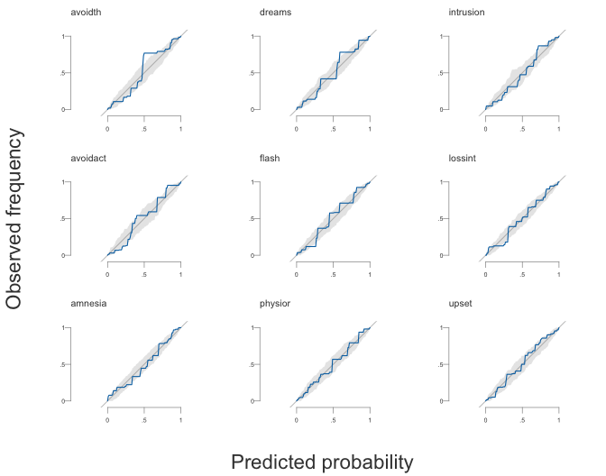

```r
plot(calibration)
```

The grey band is the wander of a model that is calibrated by construction. It is built by resampling each case’s *category* from its own predicted distribution, rather than resampling the threshold events independently: the cumulative events of one case are nested, and treating them as independent would make the band too narrow and an ordinary wander look like miscalibration.

A continuous variable has no category to have fallen in, so it gets the same question through the probability integral transform: `u = F(y | rest)`, which is uniform exactly when the conditional predictive distribution is right. Its panel is the distribution of those `u` values against the uniform diagonal, and `F` is the mixture over posterior draws, so the parameter uncertainty is inside the distribution the observation is transformed by. That band is not resampled from the model at all – under the transform the null is uniform whatever the density was – so it depends only on the number of cases. A mixed fit draws both panel kinds on one figure and records which is which in the `kind` column.

# Checking the joint distribution with simulate()

Calibrated conditional predictions do not imply that the model reproduces the joint distribution: predicting each variable from its neighbours is an easier task than reproducing how all of them covary, and a model can do the first while falling short on the second.

bgms ships no joint-level check, and the omission is deliberate. What does have diagnostic value is reading a display for systematic pattern, and that is an analyst’s judgement rather than a pass/fail statistic.

Which statistic you display matters more than it looks. Pairwise dependence statistics – correlations, covariances, cross-tabulations – sit close to the model’s sufficient set, so how they read depends on how the estimator is anchored rather than on whether the model fits. The **sum score** lies outside that set: no anchoring makes it match by construction, so a departure is about the model. It also has a one-sentence reading, which a pairwise statistic does not.

`simulate()` gives you the material. One replicated dataset per posterior draw propagates both parameter and structure uncertainty into the replicates:

```r
observed = as.matrix(data[complete.cases(data), ])

replicates = simulate(fit,
  nsim = nrow(observed), method = "posterior-sample",
  ndraws = 200, seed = 1, display_progress = "none"
)

scores = 0:(ncol(observed) * max(observed))
distribution = function(x) {
  as.numeric(table(factor(rowSums(x), levels = scores))) / nrow(x)
}

observed_share = distribution(observed)
replicated_share = vapply(replicates, distribution, observed_share)
band = apply(replicated_share, 1, quantile, probs = c(0.025, 0.975))
```

Draw the observed distribution against its pointwise band rather than counting how often the two agree. The count is the weak reading; the informative one is whether the observed curve leaves the band in a direction:

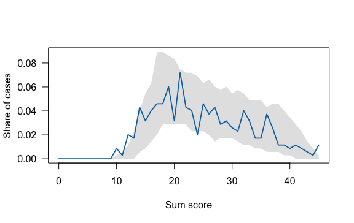

```r
plot(scores, observed_share,
  type = "n", las = 1, xlab = "Sum score", ylab = "Share of cases",
  ylim = range(c(band, observed_share))
)
polygon(c(scores, rev(scores)), c(band[1, ], rev(band[2, ])),
  col = adjustcolor("grey55", 0.25), border = NA
)
lines(scores, observed_share, col = "#0072B2", lwd = 1.8)
```

```r
mean(observed_share < band[1, ] | observed_share > band[2, ])
```

```
#> [1] 0.1086957
```

The grey band is where a dataset generated by the fitted model puts its sum scores; the blue curve is where the real one puts them. Read the shape, not the count: a curve that wanders in and out of the band is ordinary sampling variation, whereas one that sits above the band across a whole stretch of the scale and below it across another is the model getting the spread of total severity wrong, which is what a graphical model can miss while predicting each symptom from its neighbours perfectly well.

Here the departures are scattered – a few isolated scores at the sparse low end of the scale and one at the ceiling, with no run in either direction. That is the ordinary-variation reading, and the printed share is what makes the point about counts: about a tenth of the scale sits outside a 95% pointwise band, which sounds alarming and is not, because the band is pointwise and the scale has 46 points. The shape is what carries the information.

Any statistic outside the model’s sufficient set works the same way – a tail probability, the number of endorsed symptoms, whatever the substantive question turns on.

# What the three checks answer

They are three different questions, and answering one says nothing about the other two.

- `verdicts()`: which edges the data settle, and which verdicts the run is too short to settle.
- `calibration_check()`: whether to trust a prediction for one variable.
- A `simulate()`-based display: whether to trust the model as a description of the joint distribution.

An edge can be firmly settled in a model that reproduces the joint distribution poorly, and a model can predict each variable well while understating the dependence among them.

# Next steps

- The diagnostics vignette covers convergence: R-hat, effective sample size, the NUTS diagnostics, and the hierarchical prior trust gauge.
- `prior_sensitivity_check()` reports whether a verdict depends on the prior rather than on the run length, which is the other way a verdict can be unstable.